# Project7

Lakshmi Mounica Marupeddi

2024-07-22

```r
library(dplyr)
library(tidyverse)
df = read.csv("student-mat.csv", sep = ";")
head(df)
```

```
##   school sex age address famsize Pstatus Medu Fedu     Mjob     Fjob     reason
## 1     GP   F  18       U     GT3       A    4    4  at_home  teacher     course
## 2     GP   F  17       U     GT3       T    1    1  at_home    other     course
## 3     GP   F  15       U     LE3       T    1    1  at_home    other      other
## 4     GP   F  15       U     GT3       T    4    2   health services       home
## 5     GP   F  16       U     GT3       T    3    3    other    other       home
## 6     GP   M  16       U     LE3       T    4    3 services    other reputation
##   guardian traveltime studytime failures schoolsup famsup paid activities
## 1   mother          2         2        0       yes     no   no         no
## 2   father          1         2        0        no    yes   no         no
## 3   mother          1         2        3       yes     no  yes         no
## 4   mother          1         3        0        no    yes  yes        yes
## 5   father          1         2        0        no    yes  yes         no
## 6   mother          1         2        0        no    yes  yes        yes
##   nursery higher internet romantic famrel freetime goout Dalc Walc health
## 1     yes    yes       no       no      4        3     4    1    1      3
## 2      no    yes      yes       no      5        3     3    1    1      3
## 3     yes    yes      yes       no      4        3     2    2    3      3
## 4     yes    yes      yes      yes      3        2     2    1    1      5
## 5     yes    yes       no       no      4        3     2    1    2      5
## 6     yes    yes      yes       no      5        4     2    1    2      5
##   absences G1 G2 G3
## 1        6  5  6  6
## 2        4  5  5  6
## 3       10  7  8 10
## 4        2 15 14 15
## 5        4  6 10 10
## 6       10 15 15 15
```

# Question 1

```r
y = c(2, 2, 8)
x = c(0, 1, 1)
x1 = 3* x + 2

basePred = mean(y)
basePred
```

```
## [1] 4
```

```r
SSE_mean = (y - mean(y)) ^ 2 %>% sum()
SSE_mean
```

```
## [1] 24
```

```r
SSE_fit = ((y - x1)) ^ 2 %>% sum()
SSE_fit
```

```
## [1] 18
```

```r
rSquared = (SSE_mean-SSE_fit) / SSE_mean
rSquared
```

```
## [1] 0.25
```

# Question 2

Possible values of Rsquared: 0-1

# Question 3, 4

Read in the dataset by using the following code. df = read.csv(‘student-mat.csv’, sep=‘;’) How many observations are there in the dataset?

```r
dim(df)
```

```
## [1] 395  33
```

# Question 5

Create linear regression model using all the remaining variables as predictors except for G1 and G2. You can use the following code: lm1 <- lm(G3 ~ . -G1 -G2, data=df) What is the adjusted R² of the model?

```r
lm1 = lm(G3 ~  . -G1 -G2, data=df)
summary(lm1)
```

```
##
## Call:
## lm(formula = G3 ~ . - G1 - G2, data = df)
##
## Residuals:
##      Min       1Q   Median       3Q      Max
## -13.0442  -1.9028   0.4289   2.7570   8.8874
##
## Coefficients:
##                  Estimate Std. Error t value Pr(>|t|)
## (Intercept)      14.07769    4.48089   3.142  0.00182 **
## schoolMS          0.72555    0.79157   0.917  0.35997
## sexM              1.26236    0.50003   2.525  0.01202 *
## age              -0.37516    0.21721  -1.727  0.08501 .
## addressU          0.55135    0.58412   0.944  0.34586
## famsizeLE3        0.70281    0.48824   1.439  0.15090
## PstatusT         -0.32010    0.72390  -0.442  0.65862
## Medu              0.45687    0.32317   1.414  0.15833
## Fedu             -0.10458    0.27762  -0.377  0.70663
## Mjobhealth        0.99808    1.11819   0.893  0.37268
## Mjobother        -0.35900    0.71316  -0.503  0.61500
## Mjobservices      0.65832    0.79784   0.825  0.40985
## Mjobteacher      -1.24149    1.03821  -1.196  0.23257
## Fjobhealth        0.34767    1.43796   0.242  0.80909
## Fjobother        -0.61967    1.02304  -0.606  0.54509
## Fjobservices     -0.46577    1.05697  -0.441  0.65972
## Fjobteacher       1.32619    1.29654   1.023  0.30707
## reasonhome        0.07851    0.55380   0.142  0.88735
## reasonother       0.77707    0.81757   0.950  0.34252
## reasonreputation  0.61304    0.57657   1.063  0.28839
## guardianmother    0.06978    0.54560   0.128  0.89830
## guardianother     0.75010    0.99946   0.751  0.45345
## traveltime       -0.24027    0.33897  -0.709  0.47889
## studytime         0.54952    0.28765   1.910  0.05690 .
## failures         -1.72398    0.33291  -5.179 3.75e-07 ***
## schoolsupyes     -1.35058    0.66693  -2.025  0.04361 *
## famsupyes        -0.86182    0.47869  -1.800  0.07265 .
## paidyes           0.33975    0.47775   0.711  0.47746
## activitiesyes    -0.32953    0.44494  -0.741  0.45942
## nurseryyes       -0.17730    0.54931  -0.323  0.74706
## higheryes         1.37045    1.07780   1.272  0.20437
## internetyes       0.49813    0.61956   0.804  0.42192
## romanticyes      -1.09449    0.46925  -2.332  0.02024 *
## famrel            0.23155    0.24593   0.942  0.34706
## freetime          0.30242    0.23735   1.274  0.20345
## goout            -0.59367    0.22451  -2.644  0.00855 **
## Dalc             -0.27223    0.33087  -0.823  0.41120
## Walc              0.26339    0.24801   1.062  0.28896
## health           -0.17678    0.16101  -1.098  0.27297
## absences          0.05629    0.02897   1.943  0.05277 .
## ---
## Signif. codes:  0 '***' 0.001 '**' 0.01 '*' 0.05 '.' 0.1 ' ' 1
##
## Residual standard error: 4.108 on 355 degrees of freedom
## Multiple R-squared:  0.2756, Adjusted R-squared:  0.196
## F-statistic: 3.463 on 39 and 355 DF,  p-value: 3.317e-10
```

# Question 6

Which of the following variables are significant according to lm1? Assume 1 star and more to be significant. (*, **,*** are significant) 1. Sex; 2. Go out with Friends; 3. Failures

# Question 7

Coefficient of indepedent var freetime? : 0.30242

# Question 8

```r
lm2 = lm(G3~ sex + failures + goout, data=df)
summary(lm2)
```

```
##
## Call:
## lm(formula = G3 ~ sex + failures + goout, data = df)
##
## Residuals:
##      Min       1Q   Median       3Q      Max
## -12.2034  -1.7988   0.2012   2.8486   9.9461
##
## Coefficients:
##             Estimate Std. Error t value Pr(>|t|)
## (Intercept)  11.8522     0.6516  18.190  < 2e-16 ***
## sexM          1.1606     0.4279   2.712  0.00697 **
## failures     -2.1796     0.2891  -7.541  3.3e-13 ***
## goout        -0.4047     0.1935  -2.092  0.03710 *
## ---
## Signif. codes:  0 '***' 0.001 '**' 0.01 '*' 0.05 '.' 0.1 ' ' 1
##
## Residual standard error: 4.231 on 391 degrees of freedom
## Multiple R-squared:  0.1537, Adjusted R-squared:  0.1472
## F-statistic: 23.67 on 3 and 391 DF,  p-value: 4.285e-14
```

# Question 9

The adjusted R² of the model can never be greater than Multiple R². ANS: TRUE

# Question 10

Create a scatter plot of G2 vs G1. What can you say about this plot?

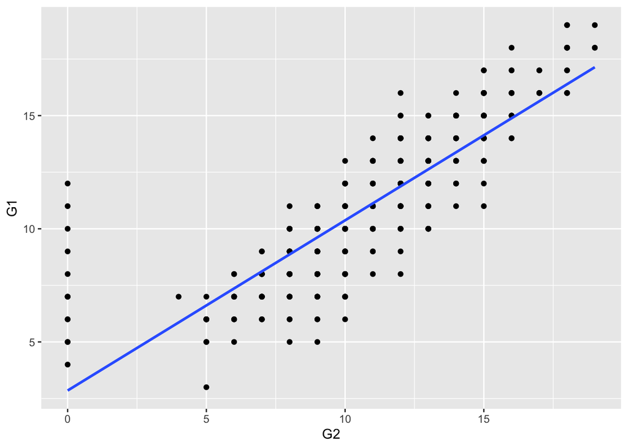

```r
df %>% ggplot(aes(x=G2,y=G1)) + geom_point() + geom_smooth(method = 'lm', se=FALSE)
```

```r
cor(df$G1, df$G2)
```

```
## [1] 0.8521181
```

# Question 11

Create a scatter plot of G3 vs G1. What can you say about this plot?

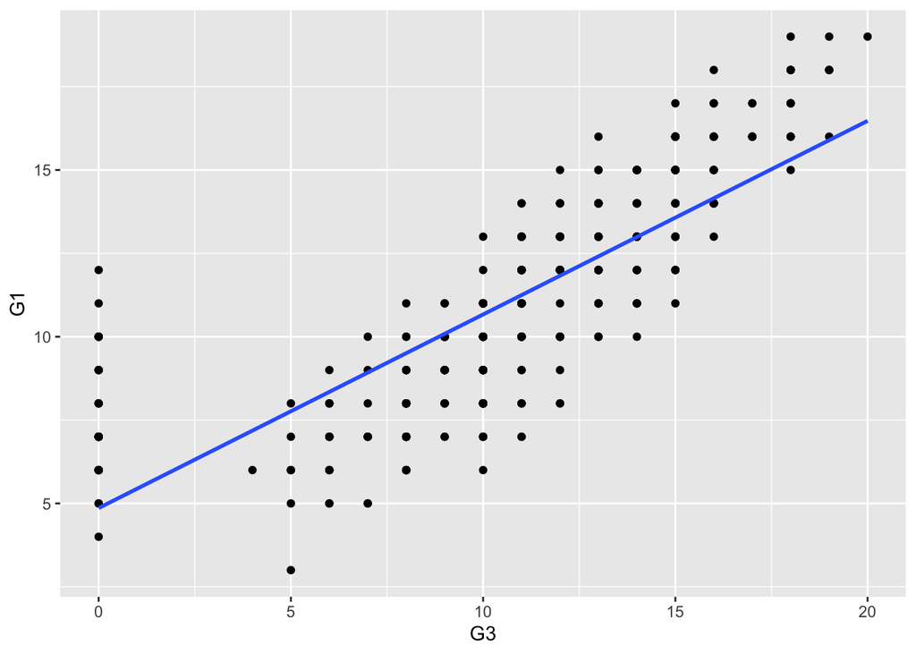

```r
df %>% ggplot(aes(x=G3,y=G1)) + geom_point() + geom_smooth(method = 'lm', se=FALSE)
```

```r
cor(df$G3, df$G1)
```

```
## [1] 0.8014679
```

# Question 12

Create a 3rd model that uses only G1 as input. What is the model adjusted R²? lm3 = lm(G3~ G1, data=df)

```r
lm3 = lm(G3~ G1, data=df)
summary(lm3)
```

```
##
## Call:
## lm(formula = G3 ~ G1, data = df)
##
## Residuals:
##      Min       1Q   Median       3Q      Max
## -11.6223  -0.8348   0.3777   1.6965   5.0153
##
## Coefficients:
##             Estimate Std. Error t value Pr(>|t|)
## (Intercept) -1.65280    0.47475  -3.481 0.000555 ***
## G1           1.10626    0.04164  26.568  < 2e-16 ***
## ---
## Signif. codes:  0 '***' 0.001 '**' 0.01 '*' 0.05 '.' 0.1 ' ' 1
##
## Residual standard error: 2.743 on 393 degrees of freedom
## Multiple R-squared:  0.6424, Adjusted R-squared:  0.6414
## F-statistic: 705.8 on 1 and 393 DF,  p-value: < 2.2e-16
```

# Question 13

Create a boxplot of G3 vs failures. Do you think adding the failures to the regression model 3 will increase adjusted R²? Which of the following options are correct?

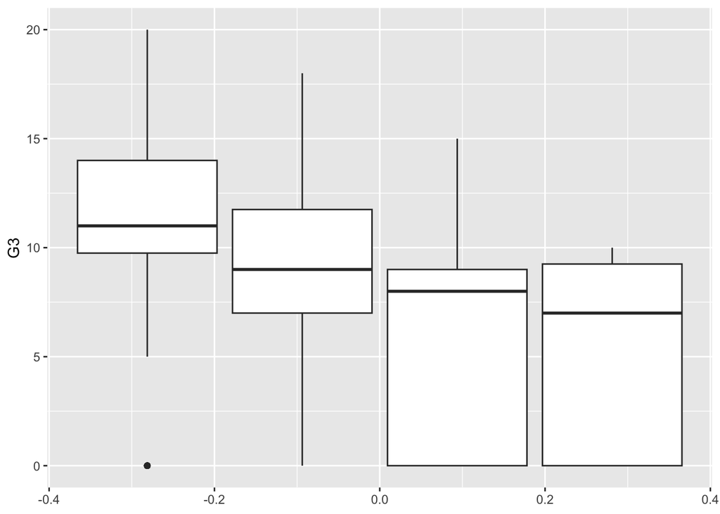

```r
df %>% ggplot(aes(group=failures, y=G3)) + geom_boxplot()
```

# Question 14

Take the 3rd model. Add failures as a predictor. So you will have G1 and failures as predictors. This will be your lm4. What is the new adjusted R²?

```r
lm4 = lm(G3~ G1 + failures, data=df)
summary(lm4)
```

```
##
## Call:
## lm(formula = G3 ~ G1 + failures, data = df)
##
## Residuals:
##      Min       1Q   Median       3Q      Max
## -10.6914  -0.8186   0.2450   1.4723   5.1725
##
## Coefficients:
##             Estimate Std. Error t value Pr(>|t|)
## (Intercept) -1.00845    0.52713  -1.913  0.05646 .
## G1           1.06362    0.04418  24.077  < 2e-16 ***
## failures    -0.53646    0.19718  -2.721  0.00681 **
## ---
## Signif. codes:  0 '***' 0.001 '**' 0.01 '*' 0.05 '.' 0.1 ' ' 1
##
## Residual standard error: 2.721 on 392 degrees of freedom
## Multiple R-squared:  0.649,  Adjusted R-squared:  0.6472
## F-statistic: 362.4 on 2 and 392 DF,  p-value: < 2.2e-16
```

# Question 15

In lm4 what is the coefficient of failures? Ans: -0.53646

# Question 16

In lm4 if the student got 10 in G1, and has 2 failures, what is the predicted G3 score going to be?

```r
coefs = lm4$coefficients
#coefs
G3 = coefs[1] + coefs[2] * 10 + coefs[3] * 2
G3
```

```
## (Intercept)
##    8.554865
```

# Question 17

From lm4 we can deduct that all else held constant, increasing G1 score by 1 point will mean an increase of G3 by 1.0636 points. True or False? Ans: True (co-ef of G1 is 1.0636)

# Question 18

From lm4 we can deduct that all else held constant, increasing failures score by 1 point will mean an increase of G3 by 1.0636 points. True or False? Ans: False (co-ef of G1 is not 1.0636)